We first have to load the Required packages.

```r
#Load required packages in the user-defined library location
.libPaths("C:/work/Rpackages/R3.2.1")
suppressMessages(library(ggplot2, quietly = T))
suppressMessages(library(dplyr, quietly = T))
suppressMessages(library(mosaicData, quietly = T))
```

The data used for this assignment is mpg or diamonds from ggplot2 package.

```r
#Show the top 6 rows of the mpg/diamonds data to know the data information
head(mpg)
```

```
##   manufacturer model displ year cyl      trans drv cty hwy fl   class
## 1         audi    a4   1.8 1999   4   auto(l5)   f  18  29  p compact
## 2         audi    a4   1.8 1999   4 manual(m5)   f  21  29  p compact
## 3         audi    a4   2.0 2008   4 manual(m6)   f  20  31  p compact
## 4         audi    a4   2.0 2008   4   auto(av)   f  21  30  p compact
## 5         audi    a4   2.8 1999   6   auto(l5)   f  16  26  p compact
## 6         audi    a4   2.8 1999   6 manual(m5)   f  18  26  p compact
```

```r
head(diamonds)
```

```
##   carat       cut color clarity depth table price    x    y    z
## 1  0.23     Ideal     E     SI2  61.5    55   326 3.95 3.98 2.43
## 2  0.21   Premium     E     SI1  59.8    61   326 3.89 3.84 2.31
## 3  0.23      Good     E     VS1  56.9    65   327 4.05 4.07 2.31
## 4  0.29   Premium     I     VS2  62.4    58   334 4.20 4.23 2.63
## 5  0.31      Good     J     SI2  63.3    58   335 4.34 4.35 2.75
## 6  0.24 Very Good     J    VVS2  62.8    57   336 3.94 3.96 2.48
```

This assignment is to create 3 plots, each to answer one question and with 3-5 iterations to show the process.

The first question is about the diamonds data: what is the price change along with the carat for different cut and clarity.

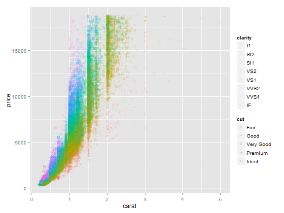

```r
#Basic Model
p <- ggplot( data=diamonds, aes(x=carat, y=price, shape = cut, color= clarity) )
#Scatter plot
 p+ geom_point( alpha=0.1 )
```

It is not very clear to see the price change if the customer has a clear requirement of clarity and cut. And it takes a long time to get the plots (over 5 mins). So we can subset the data into different group based on clarity and cut:

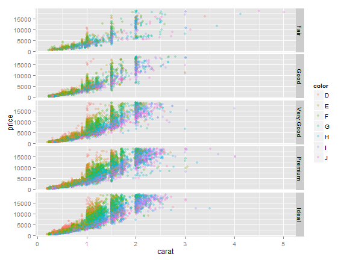

```r
#Delete the shape to speed up the generation of the plot
p2 <- ggplot( data=diamonds, aes(x=carat, y=price, color= color ) )

#Subset data to group based on clarity and cut
#First we check facet = cut~.
p2+ geom_point( alpha=0.3, size = I(2))+
   facet_grid(cut~. )
```

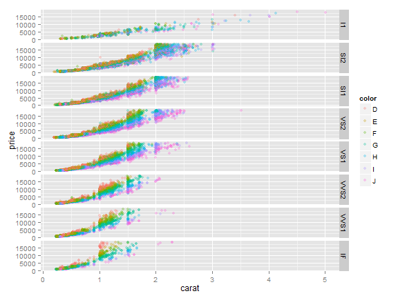

```r
#Second we check facet = clarity ~.
p2+ geom_point( alpha=0.3, size = I(2))+
   facet_grid(clarity~. )
```

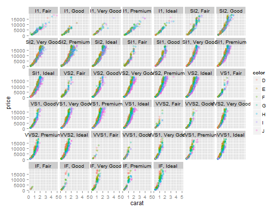

```r
#Last facet = clarity ~cut
p2+ geom_point( alpha=0.3, size = I(2))+
   facet_wrap(clarity~cut )
```

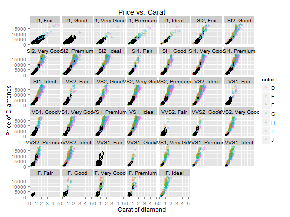

```r
#Add 2d density
#Add title
 p2+ geom_point( alpha=0.3, size = I(2))+
   facet_wrap(clarity~cut )+stat_density2d(color = "black")  +
  labs(title="Price vs. Carat", x="Carat of diamond", y="Price of Diamonds")
```

From the above plots, customers can easily find any combination of clarity and cut subgroup. Then they can further examine the price change.

Second question is: How many choices do I have if my bugget of buying a diamond is $10,000-$12,000 (the range of the diamonds data for price is $326-$18,823)?